# Jan0607 Diamond Data and Graphs

- price increases with carat weight
- clustering of data on thresholds: 1 carat, 1.5 carats, 2 carats
- you need domain knowledge (content expertise) to explain patterns
- more variation in price as weight increases

Reflection

- Every graph will have this fundamental code structure, with modifications
- copy code you have that works and modify what you need!

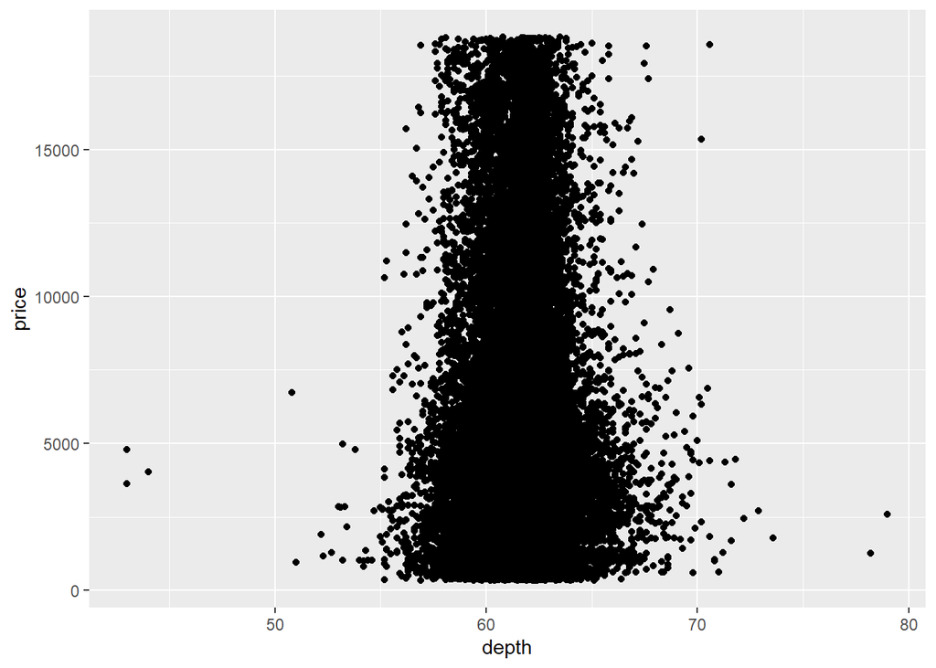

```r
ggplot(data = diamonds) + geom_point(aes(x = depth, y = price))
```

Try graphing three variables: diamond color, carat and price. How could we approach this?

- use scatterplot and symbolize the dots

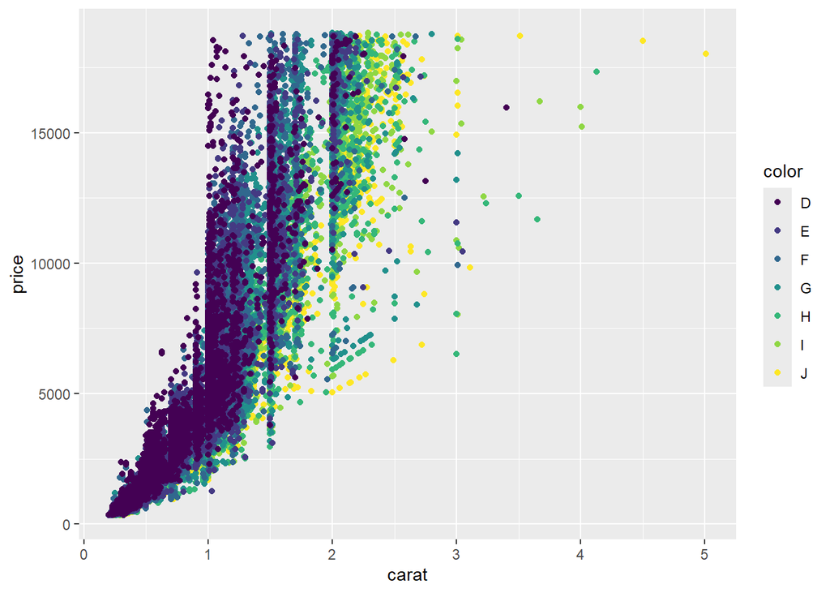

```r
ggplot(data = arrange(diamonds, desc(color))) + geom_point(aes(x = carat, y = price, color = color))
```

Interpret:

- D appears more valuable than J
- Few instances of very large D diamonds
- Note that ggplot adds each color series one by one
- many +’s in console indicates one of your lines of code is incomplete (missing parenthesis, started line with a +, etc.)

#### Facet the data

subdivide the data by a variable & create different graphs for each subgroup

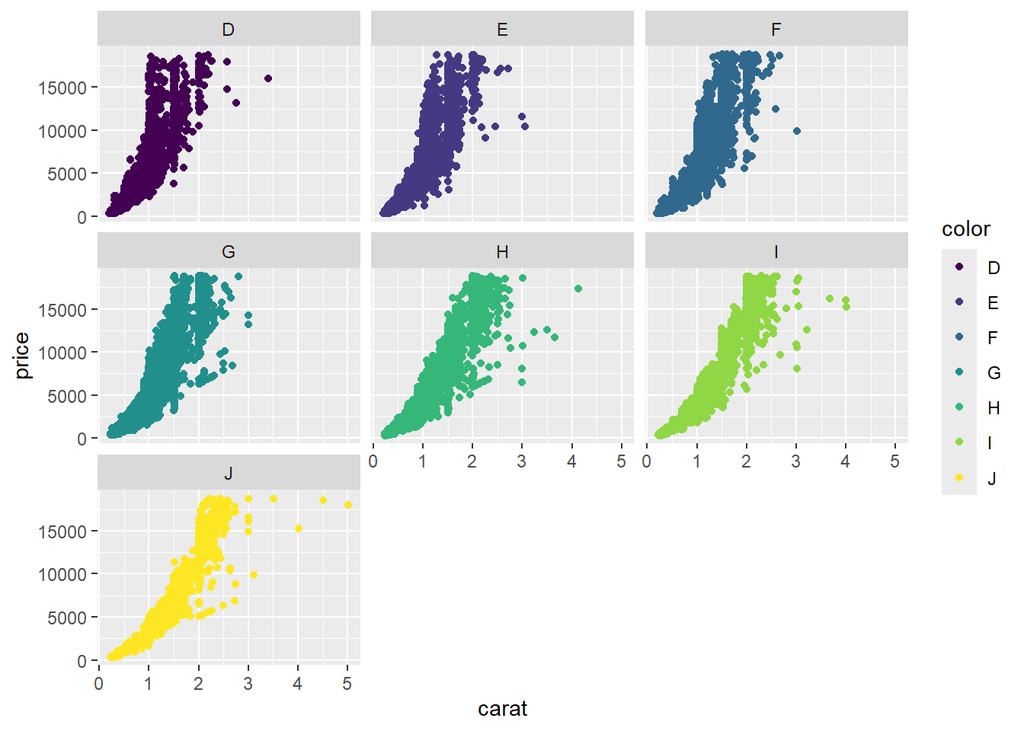

```r
ggplot(data = diamonds) +
  geom_point(aes(x = carat, y = price, color = color)) +
  facet_wrap(~color)
```

Interpret:

- now it’s possible to analyze trends of each color separately
- maybe facet by cut instead

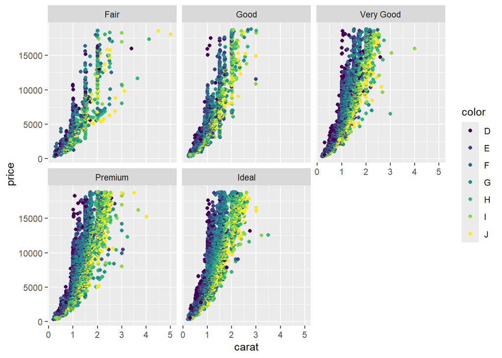

```r
ggplot(data = diamonds) +
  geom_point(aes(x = carat, y = price, color = color)) +
  facet_wrap(~cut)
```

Interpret:

- as cut improves, price gets better
- price improves faster by carat for better cuts

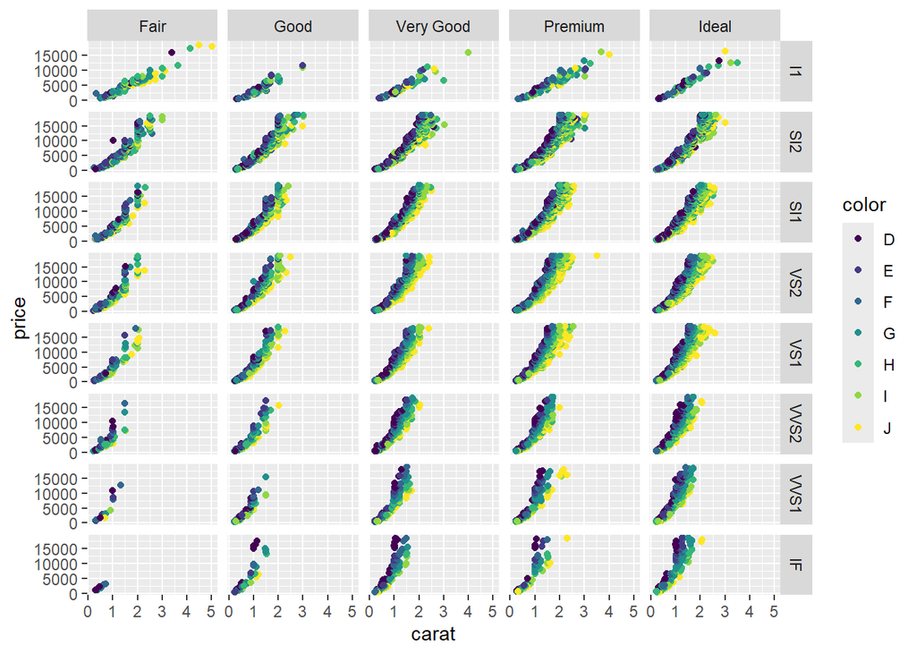

```r
ggplot(data = diamonds) +
  geom_point(aes(x = carat, y = price, color = color)) +
  facet_grid(clarity~cut)
```

# January 7: Continue Graphing Diamonds

## Restart R and Remake last graph

If you get an error about a function not being found, you either mistyped its name or more likely, you need to load the library in which the function is found. You need to do this every time you open a new R session.

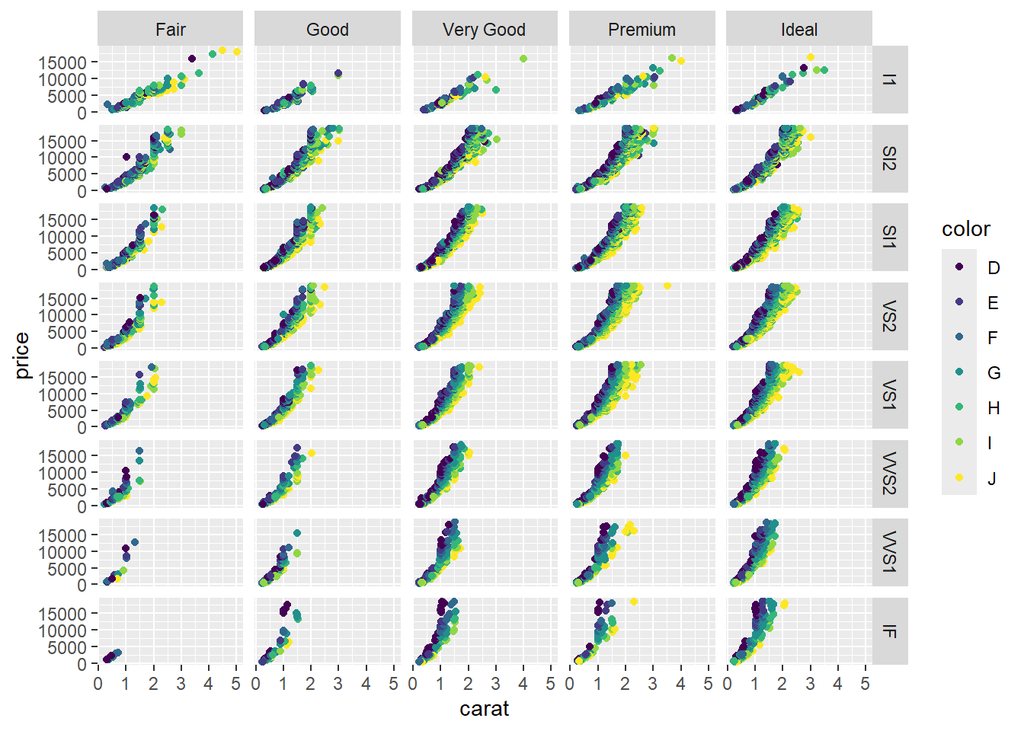

```r
ggplot(data = diamonds) +
  geom_point(aes(x = carat, y = price, color = color)) +
  facet_grid(clarity~cut)
```

ctrl+shift+r can add a section to an R script. Headings take the place of that in Rmd